# Machine Learning Project

LuAnn Born

Friday, December 19, 2014

**Overview**

This project will explore data obtained from six subjects that performed barbell lifts. The data used included 160 variables including measurements from accelerometers on the subjects’ belt, forearm, arm and dumbbell.

**Model Development**

After examining the training and testing sets it was determined that only 52 variables were actually applicable, since the testing set did not include rolled up statistical data such as means, variances, standard deviations, etc. that were present in the training set. Other excluded variables were the timestamps and min and max variables.

After narrowing down the possible variables that might give a good model fit, a seed was used to produce reproducible results and the model was trained with the training data using the Random Forest algorithm, the classe variable as the outcome and the 52 variables that actually had data in the testing set for predictors.

Once this completed the variable importance (varImp) function was run to determine which variables might be most informative. Predictions were made with the caret function predict on the model using the pml.testing data set. I had a 100% success rate in the submission phase of this project.

```r
PkgNames <- c("ElemStatLearn", "caret", "randomForest", "stats")
invisible(suppressMessages(suppressWarnings(lapply(PkgNames, require, character.only = T))))
pml.training <- read.csv("pml-training.csv")
pml.testing <- read.csv("pml-testing.csv")
inTrain <- createDataPartition(y=pml.training$classe, p=0.7, list=FALSE)
training <- pml.training[inTrain,]
testing <- pml.training[-inTrain,]
set.seed(10901)
Sys.time()
```

```
## [1] "2014-12-20 11:41:05 EST"
```

```r
treeMod1 = train(classe ~roll_belt+pitch_belt+yaw_belt+total_accel_belt+
                   gyros_belt_x+gyros_belt_y+gyros_belt_z+accel_belt_x+
                   accel_belt_y+accel_belt_z+magnet_belt_x+magnet_belt_y+
                   magnet_belt_z+roll_arm+pitch_arm+yaw_arm+total_accel_arm+
                   gyros_arm_x+gyros_arm_y+gyros_arm_z+accel_arm_x+
                   accel_arm_y+accel_arm_z+magnet_arm_x+magnet_arm_y+
                   magnet_arm_z+roll_dumbbell+pitch_dumbbell+yaw_dumbbell+
                   total_accel_dumbbell+gyros_dumbbell_x+gyros_dumbbell_y+
                   gyros_dumbbell_z+accel_dumbbell_x+accel_dumbbell_y+
                   accel_dumbbell_z+magnet_dumbbell_x+magnet_dumbbell_y+
                   magnet_dumbbell_z+roll_forearm+pitch_forearm+yaw_forearm+
                   total_accel_forearm+gyros_forearm_x+gyros_forearm_y+
                   gyros_forearm_z+accel_forearm_x+accel_forearm_y+
                   accel_forearm_z+magnet_forearm_x+magnet_forearm_y+magnet_forearm_z,
                   method="rf", data=training)
Sys.time()
```

```
## [1] "2014-12-20 12:38:01 EST"
```

```r
varImp(treeMod1)
```

```
## rf variable importance
##
##   only 20 most important variables shown (out of 52)
##
##                      Overall
## roll_belt             100.00
## pitch_forearm          60.42
## yaw_belt               54.23
## pitch_belt             44.74
## roll_forearm           43.91
## magnet_dumbbell_z      43.70
## magnet_dumbbell_y      43.04
## accel_dumbbell_y       21.92
## magnet_dumbbell_x      18.95
## accel_forearm_x        17.83
## roll_dumbbell          15.87
## magnet_belt_z          15.33
## accel_dumbbell_z       14.24
## magnet_forearm_z       13.98
## magnet_belt_y          13.51
## accel_belt_z           13.50
## total_accel_dumbbell   12.55
## yaw_arm                11.13
## gyros_belt_z           10.88
## magnet_belt_x          10.39
```

```r
print(treeMod1$finalModel)
```

```
##
## Call:
##  randomForest(x = x, y = y, mtry = param$mtry)
##                Type of random forest: classification
##                      Number of trees: 500
## No. of variables tried at each split: 27
##
##         OOB estimate of  error rate: 0.76%
## Confusion matrix:
##      A    B    C    D    E class.error
## A 3900    5    1    0    0 0.001536098
## B   25 2624    9    0    0 0.012791573
## C    0   14 2370   12    0 0.010851419
## D    0    2   24 2224    2 0.012433393
## E    0    1    4    5 2515 0.003960396
```

```r
head(treeMod1$resample)
```

```
##    Accuracy     Kappa   Resample
## 1 0.9862313 0.9825732 Resample04
## 2 0.9846002 0.9805030 Resample09
## 3 0.9878268 0.9846176 Resample05
## 4 0.9913978 0.9891414 Resample01
## 5 0.9892494 0.9863787 Resample10
## 6 0.9894443 0.9866548 Resample06
```

```r
confusionMatrix(testing$classe, predict(treeMod1,testing))
```

```
## Confusion Matrix and Statistics
##
##           Reference
## Prediction    A    B    C    D    E
##          A 1672    1    0    0    1
##          B    9 1130    0    0    0
##          C    0   10 1014    2    0
##          D    0    0    9  954    1
##          E    0    0    1    0 1081
##
## Overall Statistics
##
##                Accuracy : 0.9942
##                  95% CI : (0.9919, 0.996)
##     No Information Rate : 0.2856
##     P-Value [Acc > NIR] : < 2.2e-16
##
##                   Kappa : 0.9927
##  Mcnemar's Test P-Value : NA
##
## Statistics by Class:
##
##                      Class: A Class: B Class: C Class: D Class: E
## Sensitivity            0.9946   0.9904   0.9902   0.9979   0.9982
## Specificity            0.9995   0.9981   0.9975   0.9980   0.9998
## Pos Pred Value         0.9988   0.9921   0.9883   0.9896   0.9991
## Neg Pred Value         0.9979   0.9977   0.9979   0.9996   0.9996
## Prevalence             0.2856   0.1939   0.1740   0.1624   0.1840
## Detection Rate         0.2841   0.1920   0.1723   0.1621   0.1837
## Detection Prevalence   0.2845   0.1935   0.1743   0.1638   0.1839
## Balanced Accuracy      0.9971   0.9942   0.9939   0.9979   0.9990
```

```r
predict(treeMod1, pml.testing)
```

```
##  [1] B A B A A E D B A A B C B A E E A B B B
## Levels: A B C D E
```

```r
Sys.time()
```

```
## [1] "2014-12-20 12:38:01 EST"
```

```r
treeMod2 = train(classe ~roll_belt+pitch_belt+yaw_belt+gyros_belt_z+accel_belt_z+
                   magnet_belt_y+magnet_belt_z+roll_arm+roll_dumbbell+yaw_dumbbell+
                   total_accel_dumbbell+accel_dumbbell_x+accel_dumbbell_y+
                   accel_dumbbell_z+magnet_dumbbell_x+magnet_dumbbell_y+
                   magnet_dumbbell_z+roll_forearm+pitch_forearm+accel_forearm_x, method="rf",
                   data=training)
Sys.time()
```

```
## [1] "2014-12-20 12:58:41 EST"
```

```r
varImp(treeMod2)
```

```
## rf variable importance
##
##                      Overall
## roll_belt            100.000
## yaw_belt              77.644
## magnet_dumbbell_z     62.769
## pitch_belt            57.756
## pitch_forearm         56.916
## magnet_dumbbell_y     48.039
## roll_forearm          46.663
## magnet_dumbbell_x     34.755
## accel_belt_z          23.074
## magnet_belt_z         22.223
## magnet_belt_y         21.379
## accel_dumbbell_y      20.215
## roll_dumbbell         18.548
## accel_forearm_x       18.256
## accel_dumbbell_z      15.887
## roll_arm              15.159
## gyros_belt_z           7.850
## accel_dumbbell_x       4.634
## yaw_dumbbell           4.093
## total_accel_dumbbell   0.000
```

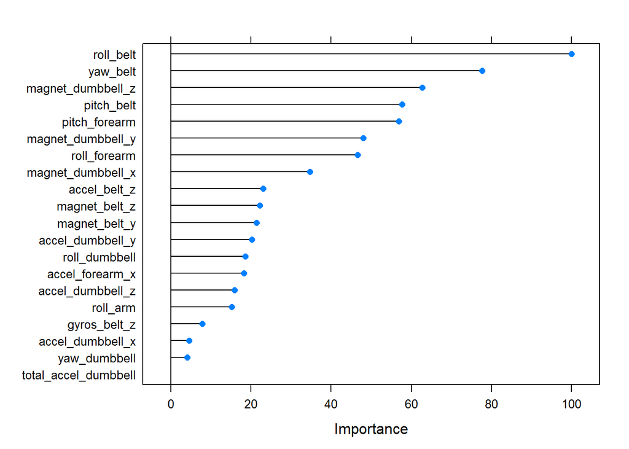

```r
plot(varImp(treeMod2))
```

```r
print(treeMod2$finalModel)
```

```
##
## Call:
##  randomForest(x = x, y = y, mtry = param$mtry)
##                Type of random forest: classification
##                      Number of trees: 500
## No. of variables tried at each split: 2
##
##         OOB estimate of  error rate: 1.17%
## Confusion matrix:
##      A    B    C    D    E class.error
## A 3892    9    2    3    0 0.003584229
## B   27 2599   30    1    1 0.022197141
## C    0   26 2354   16    0 0.017529215
## D    1    0   29 2218    4 0.015097691
## E    0    2    3    7 2513 0.004752475
```

```r
head(treeMod2$resample)
```

```
##    Accuracy     Kappa   Resample
## 1 0.9822300 0.9775321 Resample09
## 2 0.9835187 0.9791976 Resample05
## 3 0.9806935 0.9755898 Resample01
## 4 0.9816314 0.9767291 Resample10
## 5 0.9848006 0.9807792 Resample06
## 6 0.9822974 0.9775861 Resample02
```

```r
confusionMatrix(testing$classe, predict(treeMod2,testing))
```

```
## Confusion Matrix and Statistics
##
##           Reference
## Prediction    A    B    C    D    E
##          A 1667    7    0    0    0
##          B   10 1117   12    0    0
##          C    0   16 1004    6    0
##          D    0    0    8  955    1
##          E    0    0    3    0 1079
##
## Overall Statistics
##
##                Accuracy : 0.9893
##                  95% CI : (0.9863, 0.9918)
##     No Information Rate : 0.285
##     P-Value [Acc > NIR] : < 2.2e-16
##
##                   Kappa : 0.9865
##  Mcnemar's Test P-Value : NA
##
## Statistics by Class:
##
##                      Class: A Class: B Class: C Class: D Class: E
## Sensitivity            0.9940   0.9798   0.9776   0.9938   0.9991
## Specificity            0.9983   0.9954   0.9955   0.9982   0.9994
## Pos Pred Value         0.9958   0.9807   0.9786   0.9907   0.9972
## Neg Pred Value         0.9976   0.9952   0.9953   0.9988   0.9998
## Prevalence             0.2850   0.1937   0.1745   0.1633   0.1835
## Detection Rate         0.2833   0.1898   0.1706   0.1623   0.1833
## Detection Prevalence   0.2845   0.1935   0.1743   0.1638   0.1839
## Balanced Accuracy      0.9962   0.9876   0.9865   0.9960   0.9992
```

```r
predict(treeMod2, pml.testing)
```

```
##  [1] B A B A A E D B A A B C B A E E A B B B
## Levels: A B C D E
```

```r
Sys.time()
```

```
## [1] "2014-12-20 12:58:42 EST"
```

```r
treeMod3 = train(classe ~roll_belt+yaw_belt+magnet_dumbbell_z+magnet_dumbbell_y+pitch_belt+
                   pitch_forearm+magnet_dumbbell_x+roll_forearm+accel_belt_z+accel_dumbbell_y,
                   method="rf", data=training)
Sys.time()
```

```
## [1] "2014-12-20 13:09:45 EST"
```

```r
varImp(treeMod3)
```

```
## rf variable importance
##
##                   Overall
## roll_belt         100.000
## yaw_belt           64.779
## pitch_belt         41.160
## pitch_forearm      32.691
## magnet_dumbbell_z  28.600
## magnet_dumbbell_y  14.893
## roll_forearm        9.407
## magnet_dumbbell_x   2.728
## accel_belt_z        2.042
## accel_dumbbell_y    0.000
```

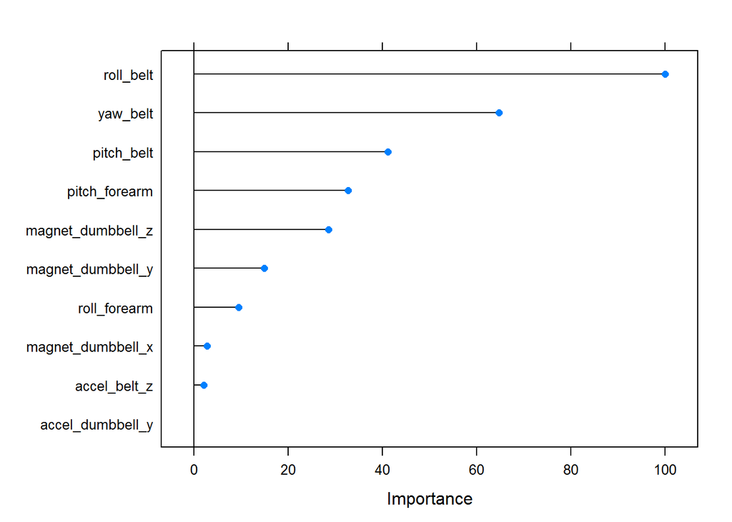

```r
plot(varImp(treeMod3))
```

```r
print(treeMod3$finalModel)
```

```
##
## Call:
##  randomForest(x = x, y = y, mtry = param$mtry)
##                Type of random forest: classification
##                      Number of trees: 500
## No. of variables tried at each split: 2
##
##         OOB estimate of  error rate: 1.38%
## Confusion matrix:
##      A    B    C    D    E class.error
## A 3874   15   13    4    0 0.008192524
## B   26 2589   33   10    0 0.025959368
## C    2   23 2354   17    0 0.017529215
## D    1    0   22 2226    3 0.011545293
## E    0   11    4    6 2504 0.008316832
```

```r
head(treeMod3$resample)
```

```
##    Accuracy     Kappa   Resample
## 1 0.9755134 0.9690478 Resample09
## 2 0.9848907 0.9808476 Resample05
## 3 0.9784946 0.9728258 Resample01
## 4 0.9793199 0.9738365 Resample10
## 5 0.9793103 0.9738277 Resample06
## 6 0.9786982 0.9730542 Resample02
```

```r
confusionMatrix(testing$classe, predict(treeMod3,testing))
```

```
## Confusion Matrix and Statistics
##
##           Reference
## Prediction    A    B    C    D    E
##          A 1665    9    0    0    0
##          B   11 1110   14    4    0
##          C    1   14 1007    4    0
##          D    0    0    7  956    1
##          E    0    1    1    0 1080
##
## Overall Statistics
##
##                Accuracy : 0.9886
##                  95% CI : (0.9856, 0.9912)
##     No Information Rate : 0.285
##     P-Value [Acc > NIR] : < 2.2e-16
##
##                   Kappa : 0.9856
##  Mcnemar's Test P-Value : NA
##
## Statistics by Class:
##
##                      Class: A Class: B Class: C Class: D Class: E
## Sensitivity            0.9928   0.9788   0.9786   0.9917   0.9991
## Specificity            0.9979   0.9939   0.9961   0.9984   0.9996
## Pos Pred Value         0.9946   0.9745   0.9815   0.9917   0.9982
## Neg Pred Value         0.9972   0.9949   0.9955   0.9984   0.9998
## Prevalence             0.2850   0.1927   0.1749   0.1638   0.1837
## Detection Rate         0.2829   0.1886   0.1711   0.1624   0.1835
## Detection Prevalence   0.2845   0.1935   0.1743   0.1638   0.1839
## Balanced Accuracy      0.9954   0.9864   0.9874   0.9950   0.9993
```

```r
predict(treeMod3, pml.testing)
```

```
##  [1] B A B A A E D B A A B C B A E E A B B B
## Levels: A B C D E
```

```r
Sys.time()
```

```
## [1] "2014-12-20 13:09:46 EST"
```

```r
treeMod = train(classe ~roll_belt+yaw_belt+pitch_belt+pitch_forearm+magnet_dumbbell_z,
                  method="rf", data=training)
Sys.time()
```

```
## [1] "2014-12-20 13:17:17 EST"
```

```r
varImp(treeMod)
```

```
## rf variable importance
##
##                   Overall
## roll_belt          100.00
## yaw_belt            55.10
## magnet_dumbbell_z   18.42
## pitch_belt          12.10
## pitch_forearm        0.00
```

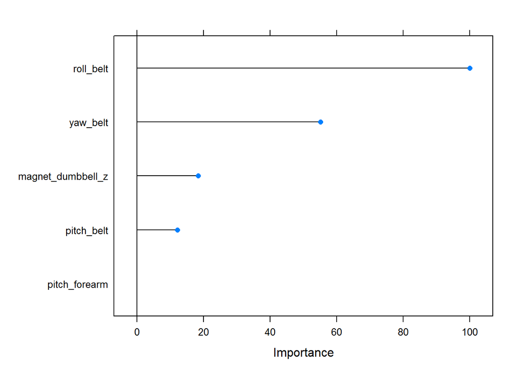

```r
plot(varImp(treeMod))
```

```r
print(treeMod$finalModel)
```

```
##
## Call:
##  randomForest(x = x, y = y, mtry = param$mtry)
##                Type of random forest: classification
##                      Number of trees: 500
## No. of variables tried at each split: 2
##
##         OOB estimate of  error rate: 3.04%
## Confusion matrix:
##      A    B    C    D    E class.error
## A 3817   34   33   14    8  0.02278546
## B   40 2524   64   24    6  0.05041384
## C   11   41 2319   23    2  0.03213689
## D   13    4   38 2189    8  0.02797513
## E    6   28    9   12 2470  0.02178218
```

```r
head(treeMod$resample)
```

```
##    Accuracy     Kappa   Resample
## 1 0.9592402 0.9484810 Resample09
## 2 0.9616525 0.9514737 Resample05
## 3 0.9543452 0.9422460 Resample01
## 4 0.9590444 0.9481645 Resample10
## 5 0.9591313 0.9483086 Resample06
## 6 0.9587138 0.9477745 Resample02
```

```r
confusionMatrix(testing$classe, predict(treeMod,testing))
```

```
## Confusion Matrix and Statistics
##
##           Reference
## Prediction    A    B    C    D    E
##          A 1647   12   11    4    0
##          B   21 1077   35    6    0
##          C    4    8 1005    9    0
##          D    2    1   12  947    2
##          E    4   15    3    6 1054
##
## Overall Statistics
##
##                Accuracy : 0.9737
##                  95% CI : (0.9692, 0.9776)
##     No Information Rate : 0.2851
##     P-Value [Acc > NIR] : < 2.2e-16
##
##                   Kappa : 0.9667
##  Mcnemar's Test P-Value : 1.511e-07
##
## Statistics by Class:
##
##                      Class: A Class: B Class: C Class: D Class: E
## Sensitivity            0.9815   0.9677   0.9428   0.9743   0.9981
## Specificity            0.9936   0.9870   0.9956   0.9965   0.9942
## Pos Pred Value         0.9839   0.9456   0.9795   0.9824   0.9741
## Neg Pred Value         0.9926   0.9924   0.9874   0.9949   0.9996
## Prevalence             0.2851   0.1891   0.1811   0.1652   0.1794
## Detection Rate         0.2799   0.1830   0.1708   0.1609   0.1791
## Detection Prevalence   0.2845   0.1935   0.1743   0.1638   0.1839
## Balanced Accuracy      0.9876   0.9773   0.9692   0.9854   0.9962
```

```r
predict(treeMod, pml.testing)
```

```
##  [1] B A B A A E D B A A B C B A E E A B B B
## Levels: A B C D E
```

As can be seen from the above, random forest does not necessarily require cross validations. The documentation states that it is performed internally as part of the function. Regardless, I did use the training set to cross validate by splitting that into training and testing data sets. The original model worked effectively and gave 100% accuracy in the pml.testing data set. The out of bag expected error rates, accuracies, and times to compile the model are given below for the models using the cross validated training and testing data sets for a previous run and are as follows:

treeMod1 | 0.79% | 99.51% | 54 mins.

treeMod2 | 1.16% | 99.01% | 20 mins.

treeMod3 | 1.38% | 98.88% | 12 mins.

treeMod | 2.98% | 96.89% | 7 mins.

The biggest variable found in model selection was the time factor and so for the sake of speed in the case of small data sets the treeMod model would be the best choice. Accuracy would prove to be more of a problem once there the data size reaches into the hundreds of records. In that case one of the other models could be chosen to guarantee a higher accuracy rate.